# Week 1: TE 1- 4 HW

Fatima Fairfax

1/5/2022

# Chapter 3 Question - Variables

1. What is a variable?

A variable is a collection of observations of the same measure.

2. What type of variables are the following?
1. Age – continuous (though typically taken in count form)
2. Gender – categorical
3. The number of times that the President has tweeted in the past day – count
4. Income – continuous
5. Number of Instagram posts about statistics in the past month – count
6. The number of unemployment claims filed in US last week – count
7. The university or college that a student attends – categorical
8. A therapist’s written assessment of a patient’s symptoms of depression – qualitative
9. Whether a soccer team is in its league’s A division (highest), B division (next highest), or C division (lowest) – ordinal
3. Which of the following provides a description of the probability that each value of a variable will occur?

distribution

4. From the provided frequency table, provide the following:

```r
salary <- c(85000, 90000,100000,120000,125000,130000)
freq <- c(5,4,1,2,3,2)

tab_4 <- data.frame(salary,freq)

tab_4
```

```
##   salary freq
## 1  85000    5
## 2  90000    4
## 3 100000    1
## 4 120000    2
## 5 125000    3
## 6 130000    2
```

1. Calculate the average salary earned by professors

```r
avg_sal <- sum((tab_4$salary)*(tab_4$freq)) / sum(tab_4$freq)

avg_sal
```

```
## [1] 103529.4
```

The average salary is $103,529

2. Calculate the median

This data set has 17 values. The Median is the 9th value.

Median = $90,000

3. Calculate the minimum and maximum

This is just the lowest and highest value in the data set:

Minimum = $85,000 Maximum = $130,000

4. Calculate the interquartile range

The 25th quartile = $85,000 The 75th quartile = $125,000

IQR = 125,000 - 85,000 = $40,000.

50% of the employees closest the median have a range of average salaries of $40,000

I can do a long way check of all of this by converting the frequency table to one list frame and using the summary function:

```r
list_4 <- matrix(rep(tab_4$salary, times=tab_4$freq), ncol=1, byrow=TRUE)

summary(list_4)
```

```
##        V1
##  Min.   : 85000
##  1st Qu.: 85000
##  Median : 90000
##  Mean   :103529
##  3rd Qu.:125000
##  Max.   :130000
```

This gives a median of $90,000, min = $85,00; max = $130,000 and interquartile range of $125,000 - $85,000 = $40,000.

5. Which of the following commonly represents the truth we are trying to estimate in statistics?
3. Greek letters like $\mu$ and $\beta$
6. Which of the following reduces impact of extreme values if the distribution of a variable is skewed?
1. Log transforming the variable
7. Order the following distribution from the one with lowest to the one with highest variability:

d < a < c < b

# Chapter 4 Question - Describing Relationships

## Coding Exercise

First, I load the packages associated with this textbook:

```r
install.packages('causaldata',repos="https://cran.us.r-project.org")
```

Using a dataset of women’s labor force participation and earnings from 1975 I will: a) load in the data b) draw scatterplot between women’s earnings and household earnings c) get the conditional mean of women’s earnings on if they attended college d) get the conditional mean of women’s earnings on bins of household earning e) draw the LOESS and linear regression curves of the mean of log earnings conditional on log household earning f) run a linear regression of log earnings on log household earning by itself and with controls

```r
#loading libraries

library(tidyverse)
install.packages('modelsummary',repos = "https://cran.us.r-project.org")
library(modelsummary)
```

```r
#getting relevant data from the full data set

df <- causaldata::Mroz |>
  # keep just working women
  dplyr::filter(lfp == TRUE) |>
  # get unlogged earnings
  mutate(earn = exp(lwg))

glimpse(df)
```

```
## Rows: 428
## Columns: 9
## $ lfp  <lgl> TRUE, TRUE, TRUE, TRUE, TRUE, TRUE, TRUE, TRUE, TRUE, TRUE, TRUE,…
## $ k5   <int> 1, 0, 1, 0, 1, 0, 0, 0, 0, 0, 0, 0, 1, 0, 0, 0, 0, 0, 0, 0, 0, 0,…
## $ k618 <int> 0, 2, 3, 3, 2, 0, 2, 0, 2, 2, 1, 1, 2, 2, 1, 3, 2, 5, 0, 4, 2, 0,…
## $ age  <int> 32, 30, 35, 34, 31, 54, 37, 54, 48, 39, 33, 42, 30, 43, 43, 35, 4…
## $ wc   <lgl> FALSE, FALSE, FALSE, FALSE, TRUE, FALSE, TRUE, FALSE, FALSE, FALS…
## $ hc   <lgl> FALSE, FALSE, FALSE, FALSE, FALSE, FALSE, FALSE, FALSE, FALSE, FA…
## $ lwg  <dbl> 1.2101647, 0.3285041, 1.5141279, 0.0921151, 1.5242802, 1.5564855,…
## $ inc  <dbl> 10.910001, 19.500000, 12.039999, 6.800000, 20.100000, 9.859000, 9…
## $ earn <dbl> 3.354037, 1.388889, 4.545455, 1.096491, 4.591837, 4.742126, 8.333…
```

Looking up the Mroz data, some relevant variable terms are:

lfp = labor force participation

k5 = number of children 5 years old or younger

wc = wife attended college

lwg = log expected wages

inc = family income exclusive of wife’s income

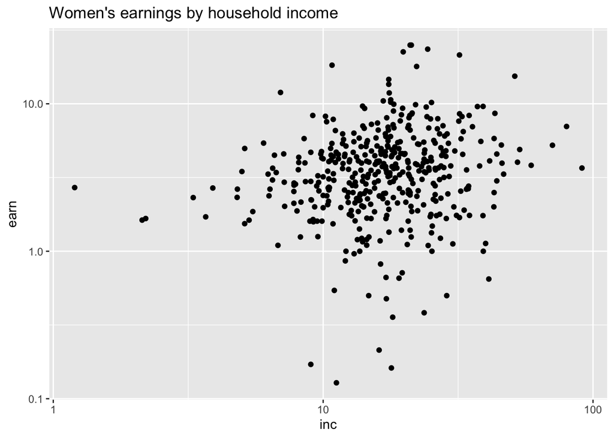

```r
#Draw scatterplot
ggplot(df,aes(x = inc, y = earn)) +
  geom_point() +
  #use log scale for both axes
  scale_x_log10() + scale_y_log10() +
  labs(title = "Women's earnings by household income")
```

```r
#conditional mean by college attendance
df |>
  group_by(wc) |>
  summarize(earn = mean(earn))
```

```
## # A tibble: 2 × 2
##   wc     earn
##   <lgl> <dbl>
## 1 FALSE  3.58
## 2 TRUE   5.35
```

```r
mean(df$earn)
```

```
## [1] 4.177677
```

The conditional mean by college attendance is 5.35 The overall mean is 4.18

```r
#conditional mean by bins of household income
df |>
  #use cut() to cut the variable into 10 bins
  mutate(inc_cut = cut(inc,10)) |>
  group_by(inc_cut) |>
  summarize(earn = mean(earn))
```

```
## # A tibble: 10 × 2
##    inc_cut       earn
##    <fct>        <dbl>
##  1 (-0.12,9.07]  3.09
##  2 (9.07,18.2]   3.83
##  3 (18.2,27.3]   4.95
##  4 (27.3,36.4]   4.56
##  5 (36.4,45.5]   4.24
##  6 (45.5,54.6]   6.14
##  7 (54.6,63.7]   3.83
##  8 (63.7,72.8]   5.23
##  9 (72.8,81.9]   7.02
## 10 (81.9,91.1]   3.67
```

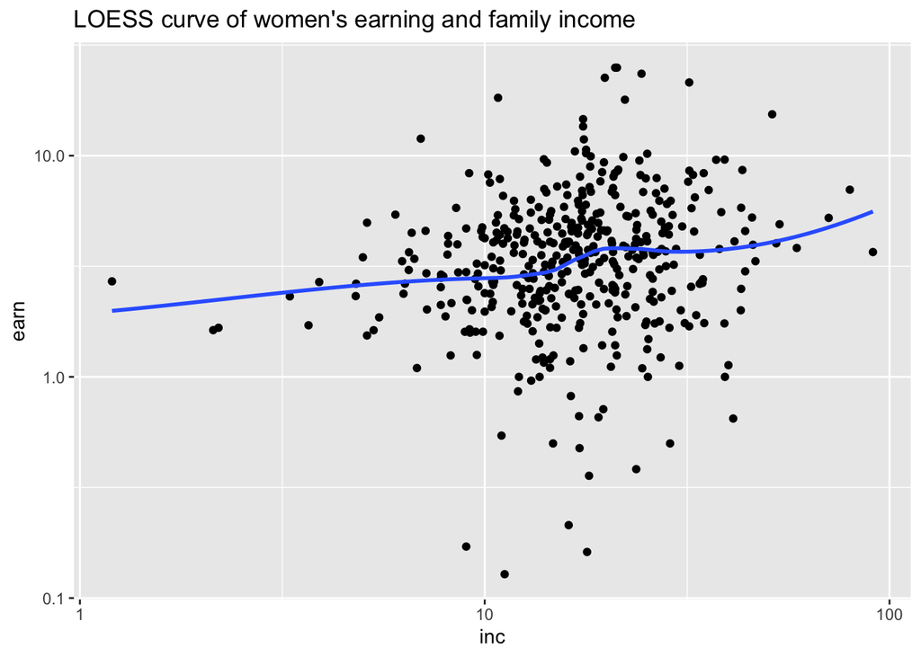

```r
#draw the LOESS and linear regression curves
ggplot(df,aes(x=inc,y=earn)) +
  geom_point() +
  #geom_smooth auto makes the LOESS curve, but we don't want the se in the graph
  geom_smooth(se = FALSE) +
  scale_x_log10() + scale_y_log10() +
  labs(title = "LOESS curve of women's earning and family income")
```

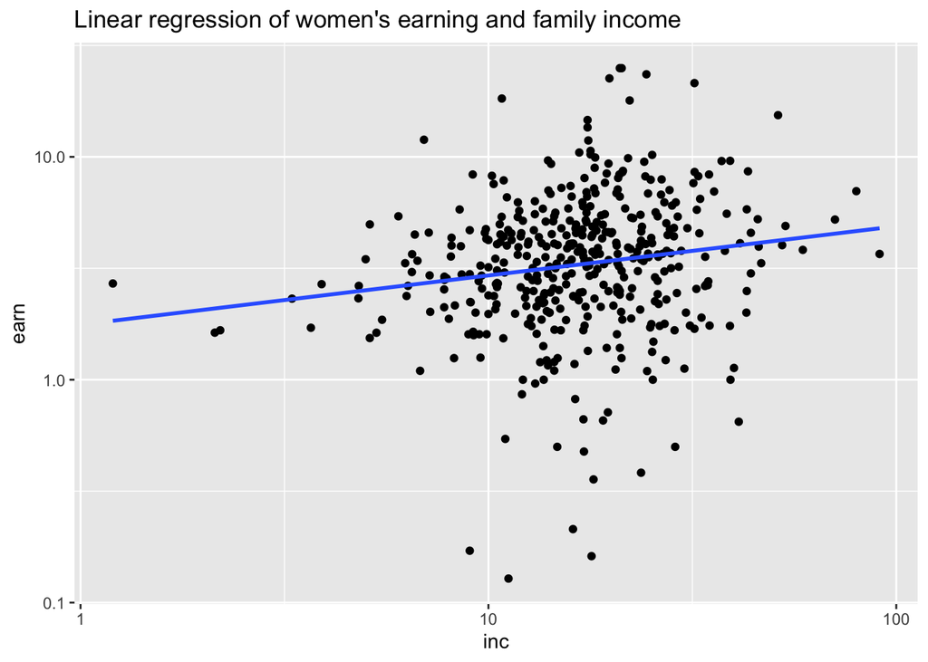

```r
ggplot(df,aes(x=inc,y=earn)) +
  geom_point() +
  geom_smooth(method = "lm",se=FALSE) +
  scale_x_log10() + scale_y_log10() +
  labs(title = "Linear regression of women's earning and family income")
```

These are very similar, but the linear regression is fitted to a straight line.

```r
#run a linear regression, by itself and including controls
model1 <- lm(lwg ~ log(inc),data = df)
model2 <- lm(lwg ~ log(inc) + wc + k5, data = df)
msummary(list(model1,model2))
```

|  | Model 1 | Model 2 |
| --- | --- | --- |
| (Intercept) | 0.569 | 0.707 |
|  | (0.185) | (0.184) |
| log(inc) | 0.221 | 0.135 |
|  | (0.065) | (0.066) |
| wcTRUE |  | 0.335 |
|  |  | (0.075) |
| k5 |  | −0.067 |
|  |  | (0.087) |
| Num.Obs. | 427 | 427 |
| R2 | 0.027 | 0.070 |
| R2 Adj. | 0.024 | 0.064 |
| AIC | 928.7 | 913.1 |
| BIC | 940.9 | 933.4 |
| Log.Lik. | −461.340 | −451.536 |
| F | 11.651 | 10.673 |

But this shows that model 2 has a larger intercept value, *meaning that when you control for college and children under 5, the log expected wages is higher.

We can also do this the Bayesian way using rstanarm.

```r
library(rstanarm)
library(broom)
library(broom.mixed)
options(mc.cores=parallel::detectCores())

b1 <- stan_glm(lwg ~ log(inc),data = df)
b2 <- stan_glm(lwg ~ log(inc) + wc + k5, data = df)
tidy(b1)
```

```
## # A tibble: 2 × 3
##   term        estimate std.error
##   <chr>          <dbl>     <dbl>
## 1 (Intercept)    0.569    0.185
## 2 log(inc)       0.221    0.0658
```

```r
tidy(b2)
```

```
## # A tibble: 4 × 3
##   term        estimate std.error
##   <chr>          <dbl>     <dbl>
## 1 (Intercept)   0.711     0.181
## 2 log(inc)      0.133     0.0662
## 3 wcTRUE        0.334     0.0806
## 4 k5           -0.0668    0.0915
```

This is decently close. The more complex model is further off.

## Chapter 4 Homework Questions

1. What is a conditional distribution?

The distribution of one variable given the value of another variable.

2. Using the fictional data on the relationship between Depression and Income level:
1. How does the conditional mean of Depression change as Income increases?

The conditional mean of Depression decreases as Income increases.

2. Does the graph indicate that lower income causes depression?

No. The graph only shows a correlation between depression and income level. This graph does not represent a display of causality.

3. Using the provided table from university students on their financial aid receipt status:

```r
#create the table

fin_aid <- c('Yes', 'No')
Freshman <- c(508,371)
Sophomore <- c(349,337)
Junior <- c(425,384)
Senior <- c(288,338)

tab_5 <- data.frame(fin_aid,Freshman,Sophomore,Junior,Senior)

tab_5
```

```
##   fin_aid Freshman Sophomore Junior Senior
## 1     Yes      508       349    425    288
## 2      No      371       337    384    338
```

1. Calculate the probability of receiving financial aid given that a student is a Senior.

```r
tab_5 |>
  group_by(fin_aid) |>
  summarize(prob_Senior = Senior / 626)
```

```
## # A tibble: 2 × 2
##   fin_aid prob_Senior
##   <chr>         <dbl>
## 1 No            0.540
## 2 Yes           0.460
```

This would look at the conditional column of being a Senior and calculating the probability of receiving financial aid. The number of seniors total is 338 + 288 = 626. Of those 288 receive financial aid. So conditional on being a senior, the probability of receiving financial aid is 288 / 626 = 0.46

2. Calculate the probability that a student is a Senior given that they receive financial aid.

This looks at the conditional row of receiving financial aid and calculating the probability of being a Senior. The number of people total who receive financial aid are 1570. Of those, 288 are Seniors. Conditional on receiving financial aid, the probability of being a Senior is 288 / 1570 = 0.18.

3. Calculate the probability of receiving financial aid given that a student is a Freshman

This is the same process of question 3a. The number of Freshman total are 508 + 371 = 879. Conditional on being a freshman, the probability of receiving financial aid is 508 / 879 = 0.58.

4. Describe two advantages and one disadvantages of using line-fitting methods as opposed to calculating local means

Advantage - line fitting gives the conditional mean of Y for any value of X, even if we don’t have data on that specific value and it let’s us cleanly describe the relationship between X and Y.

Disadvantage - you have to choose the right underlying distribution for line fitting to get an accurate assessment

5. Consider the line: $Y = 4 - 3.5X$
1. What is the conditional predicted mean of Y when X = 6

Y = 4 - 3.5 (6) = -17

2. What is the conditional predicted mean of Y when X = -2

Y = 11

6. Which term describes a measurement of how much two variables vary with each other – **covariance**
7. What is the different between covariance and correlation?

8. Based on the fictional data on math exam scores by intelligence measure collected from a sample of 100 students:
1. What type of shape is fitted in Figure A? – *a straight line*
2. What type of shape is fitted in Figure B? – *a parabola*
3. Which shape is better fit and how can you tell? – *the parabola because the data points are closer to the line (the residuals will be smaller)*
4. For figure A, describe the residuals for different ranges of math exam scores.

There are observed data both above and below the line in figure A. The ones above the line are generally further away producing higher residual values. There are more data points below the line and they are generally closer to the line, meaning the residuals are smaller but there are more of them.

9. The table below has data on 5 employees on how well they get along with coworkers and job satisfaction. The rediction variable is the predicted satisfaction level, or conditional mean of satisfaction, for each value for GetAlong derived after fitting a line of best fit using OLS:

```r
getalong <- c(4.7,4.21,5.42,4.14,3.3)
sat <- c(5.07,4.05,5.33,4.02,3.59)
pred <- c(4.72,4.28,5.38,4.22,3.45)

tab_9 <- data.frame(getalong,sat,pred)
tab_9
```

```
##   getalong  sat pred
## 1     4.70 5.07 4.72
## 2     4.21 4.05 4.28
## 3     5.42 5.33 5.38
## 4     4.14 4.02 4.22
## 5     3.30 3.59 3.45
```

1. Create a column ‘residual’ that takes the residual value for each observation:

```r
tab_9 <- tab_9 |> mutate(residual = sat - pred)

tab_9
```

```
##   getalong  sat pred residual
## 1     4.70 5.07 4.72     0.35
## 2     4.21 4.05 4.28    -0.23
## 3     5.42 5.33 5.38    -0.05
## 4     4.14 4.02 4.22    -0.20
## 5     3.30 3.59 3.45     0.14
```

2. Describe how OLS uses residuals when fitting a line

OLS fits the line that gives the lowest sum of squared residuals.

10. Consider the example: What is the relationship between first generation status and graduation rate in a population of college students?
1. Give an example of a variable that might explain why first generation status and graduation rate are correlated other than one causing the other.

A potential variable would be household income. Household income could be correlated with first generation status (as we’ve seen that holding a bachelors degree has some correlation with income) and household income may also have an impact of graduation rates, particularly around the ability to pay for the entirety of a college education.

2. Describe in five steps how you would subtract out the part of the first-generation/graduation-rate relationship that is explained by the variable you listed in part a.
1. Find the mean of first-gen status conditional on income
2. Subtract out the conditional mean to get the residual of first-gen status
3. Find the mean of graduation rate conditional on income
4. Subtract out the conditional mean to get the residual of graduation rate status
5. Describe the relationship between the residual of first-gen status and the residual of graduation rate
3. How would you interpret the first-generation/graduation-rate relationship you get after performing the steps in part b?

This relationship should be devoid of an effect of income. If the relationship between these residuals is very low or 0, then income explained a substantial part of the relationship. If there is still a strong relationship, then there is part of the relationship that is not explained by income.